# Ciclo di Carnot

Il programma carnot.py costruisce un ciclo di Carnot specificando i due valori di temperatura (T1 e T2) tra i quali il ciclo deve essere impostato.

Vedere direttamente il file del programma per informazioni sulla sua struttura dal punto di vista della programmazione *python*. Il programma viene qui utilizzato all'interno di un Jupyter notebook, lanciandolo secondo la sintassi di cui alla cella seguente:

```python
%run carnot.py
```

```python
vol.out()
```

```
Volumi iniziale e finale: 20.00 e  5.00 l
```

Il ciclo di Carnot viene costruito usando la funzione *ciclo*, che richiede come input le temperature (T1 e T2) delle due isoterme tra cui il ciclo medesimo viene fatto funzionare: ciclo(T1,T2).

La funzione calcola anche il lavoro netto prodotto dal ciclo, i flussi di calore lungo le isoterme e la resa del ciclo.

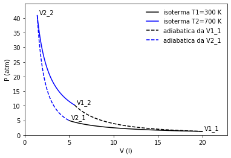

```
Coordinate del ciclo (V in litri, P in atmosfere, T in K)

V1_1: 20.00, P1_1:  1.23,  T1: 300.0
V2_1:  5.00, P2_1:  4.92,  T1: 300.0
V1_2:  5.61, P1_2: 10.23,  T2: 700.0
V2_2:  1.40, P2_2: 40.92,  T2: 700.0

Calore ceduto lungo l'isoterma T1: -825.88 cal
Calore assorbito lungo l'isoterma T2: 1927.05 cal
Lavoro netto prodotto dal ciclo: -4607.29 J

Resa del ciclo 57.14 %
```

```python
ciclo(300,700)
```

I valori di V1_1 e V2_1 possono essere cambiati usando rispettivamente le funzioni *vol.v_ini* e *vol.v_fin*. Per esempio:

```
Volume iniziale fissato a 25.00 l
Volumi iniziale e finale: 25.00 e  5.00 l
```

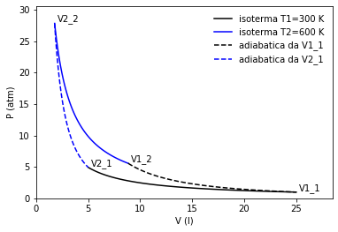

```
Coordinate del ciclo (V in litri, P in atmosfere, T in K)

V1_1: 25.00, P1_1:  0.98,  T1: 300.0
V2_1:  5.00, P2_1:  4.92,  T1: 300.0
V1_2:  8.84, P1_2:  5.57,  T2: 600.0
V2_2:  1.77, P2_2: 27.83,  T2: 600.0

Calore ceduto lungo l'isoterma T1: -958.81 cal
Calore assorbito lungo l'isoterma T2: 1917.63 cal
Lavoro netto prodotto dal ciclo: -4011.68 J

Resa del ciclo 50.00 %
```

```python
vol.v_ini(25)
vol.out()
ciclo(300,600)
```

Anzichè fissare direttamente V1_1 e V2_1, possiamo usare la funzione *pressione(T1,Pini,Pfin)* per attribuire ai due volumi i valori a cui corrispondano rispettivamente le pressioni *Pini* e *Pfin* alla temperatura T1:

```python
pressione(300,2,10)
```

```
Volume iniziale fissato a 12.30 l
Volume finale fissato a  2.46 l
```

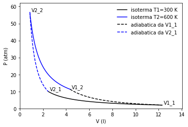

```
Coordinate del ciclo (V in litri, P in atmosfere, T in K)

V1_1: 12.30, P1_1:  2.00,  T1: 300.0
V2_1:  2.46, P2_1: 10.00,  T1: 300.0
V1_2:  4.35, P1_2: 11.31,  T2: 600.0
V2_2:  0.87, P2_2: 56.57,  T2: 600.0

Calore ceduto lungo l'isoterma T1: -958.81 cal
Calore assorbito lungo l'isoterma T2: 1917.63 cal
Lavoro netto prodotto dal ciclo: -4011.68 J

Resa del ciclo 50.00 %
```

```python
ciclo(300,600)
```